# Articulatory Analysis

Tabea Thies

2022-09-13

# Analysis of tongue body movements comparing DBS-OFF and DBS-ON

Load necessary packages

```r
library(tidyverse)
library(ggplot2)
library(lme4)
library(lmerTest)
library(merTools)
library(sjPlot)
library(sjmisc)
```

Load data set

```r
data <- read_csv('../data/articulation.csv')
```

Create subset for the comparison DBS-OFF vs DBS-ON

```r
data_red <-  filter(data, med_con %in% c('med-OFF/DBS-OFF', 'med-OFF/DBS-ON'))

data_red <- subset(data_red, speaker != "PD03")
```

# Movement duration

Descriptive stats for reporting values in Section 8.2.3

```r
DUR_stats <- data_red %>%
  group_by(med_con) %>%
  summarise(M = round(mean(GAI_V1)),
            SD = round(sd(GAI_V1)))
DUR_stats
```

```
## # A tibble: 2 x 3
##   med_con             M    SD
##   <chr>           <dbl> <dbl>
## 1 med-OFF/DBS-OFF   194    46
## 2 med-OFF/DBS-ON    198    55
```

```r
DUR_stats2 <- data_red %>%
  group_by(med_con, focus_con) %>%
  summarise(M = round(mean(GAI_V1)),
            SD = round(sd(GAI_V1)))
DUR_stats2
```

```
## # A tibble: 6 x 4
## # Groups:   med_con [2]
##   med_con         focus_con       M    SD
##   <chr>           <chr>       <dbl> <dbl>
## 1 med-OFF/DBS-OFF background    187    45
## 2 med-OFF/DBS-OFF broad         194    45
## 3 med-OFF/DBS-OFF contrastive   202    46
## 4 med-OFF/DBS-ON  background    187    54
## 5 med-OFF/DBS-ON  broad         200    56
## 6 med-OFF/DBS-ON  contrastive   205    54
```

Plot tongue body movement duration

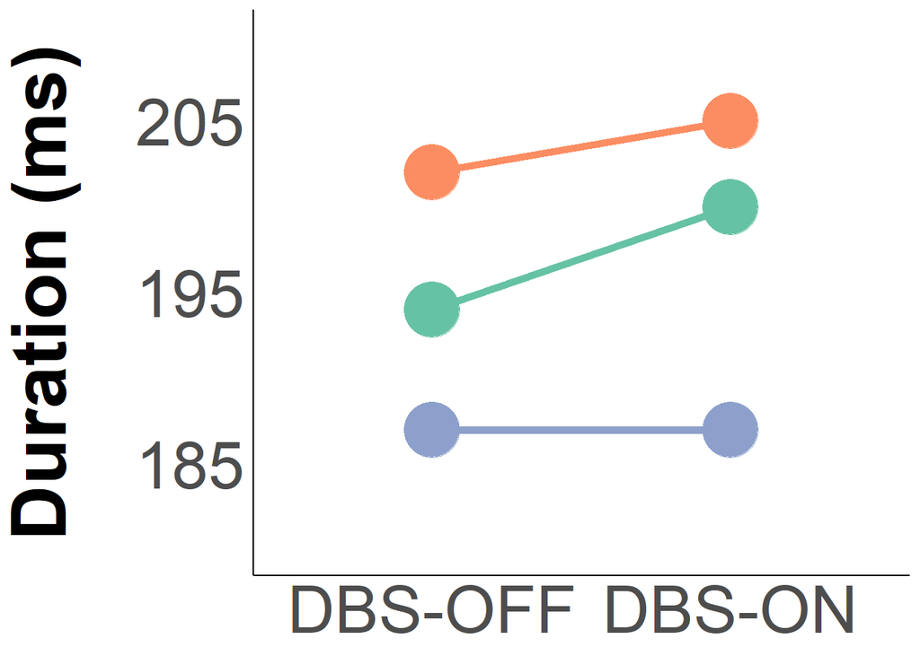

```r
DUR_stats2 %>%
  ggplot(aes(x=med_con, y=M, group = focus_con, col=focus_con)) +
  geom_line(size = 2) +
  geom_point(size = 14)+
  theme_classic() +
  theme(legend.position = 'none')+
  theme(legend.title = element_blank(),
        legend.text = element_text(size = 36))+
  scale_color_manual(values = c("#8da0cb", "#66c2a5", "#fc8d62")) +
  xlab(NULL) +
  scale_x_discrete(labels = c('DBS-OFF','DBS-ON'))+
  coord_cartesian(ylim = c(180, 210)) +
  scale_y_continuous(breaks = seq(185, 205, 10)) +
  ylab("Duration (ms)")+
  theme(axis.title.y = element_text(face = 'bold', size = 42, margin = margin(r = 30)))+
  theme(strip.text.x = element_text(size=38, face="bold"),
        strip.background = element_blank())+
  theme(axis.text.x = element_text(size = 36),
        axis.text.y = element_text(size = 36)) +
  theme(axis.ticks.x = element_blank(),
        axis.ticks.y = element_blank())
```

Create linear mixed model to investigate disease effect on TB duration

```r
mdl <- lmer(GAI_V1 ~ med_con + focus_con + vowel + cons + age  + (1 + focus_con+med_con|speaker), data_red, REML = FALSE)
```

Look at model summary

```r
summary(mdl)
```

```
## Linear mixed model fit by maximum likelihood . t-tests use Satterthwaite's
##   method [lmerModLmerTest]
## Formula: GAI_V1 ~ med_con + focus_con + vowel + cons + age + (1 + focus_con +
##     med_con | speaker)
##    Data: data_red
##
##      AIC      BIC   logLik deviance df.resid
##   7143.7   7239.6  -3550.9   7101.7      689
##
## Scaled residuals:
##     Min      1Q  Median      3Q     Max
## -3.0084 -0.6402 -0.0430  0.6410  3.5368
##
## Random effects:
##  Groups   Name                  Variance Std.Dev. Corr
##  speaker  (Intercept)            815.756 28.561
##           focus_conbroad           3.617  1.902   -0.78
##           focus_concontrastive    12.233  3.498    0.70 -0.99
##           med_conmed-OFF/DBS-ON  340.394 18.450    0.53  0.11 -0.23
##  Residual                       1181.381 34.371
## Number of obs: 710, groups:  speaker, 12
##
## Fixed effects:
##                       Estimate Std. Error       df t value Pr(>|t|)
## (Intercept)           119.7483    54.0828  13.9285   2.214 0.044010 *
## med_conmed-OFF/DBS-ON   2.7165     5.9216  12.1004   0.459 0.654546
## focus_conbroad          9.8138     3.2052 152.1125   3.062 0.002602 **
## focus_concontrastive   16.3879     3.3161  54.4226   4.942 7.76e-06 ***
## vowele                -22.0346     4.0840 686.3448  -5.395 9.42e-08 ***
## voweli                -15.7037     4.0626 686.3181  -3.865 0.000121 ***
## vowelo                -16.5549     4.1170 686.0129  -4.021 6.44e-05 ***
## vowelu                -25.8643     4.0876 685.9322  -6.327 4.50e-10 ***
## conslab               -17.5458     2.5804 685.8410  -6.800 2.28e-11 ***
## age                     1.5381     0.8963  13.6196   1.716 0.108798
## ---
## Signif. codes:  0 '***' 0.001 '**' 0.01 '*' 0.05 '.' 0.1 ' ' 1
##
## Correlation of Fixed Effects:
##             (Intr) m_-OFF fcs_cnb fcs_cnc vowele voweli vowelo vowelu conslb
## m_-OFF/DBS-  0.049
## focus_cnbrd -0.040  0.016
## fcs_cncntrs -0.006 -0.062  0.415
## vowele      -0.059  0.005  0.002   0.009
## voweli      -0.059  0.004  0.008   0.011   0.507
## vowelo      -0.039 -0.002  0.005   0.010   0.498  0.501
## vowelu      -0.049  0.004  0.003   0.003   0.503  0.506  0.498
## conslab     -0.028  0.001  0.000   0.000  -0.004 -0.002 -0.002 -0.002
## age         -0.986  0.013 -0.010   0.010   0.021  0.021  0.001  0.010  0.004
## optimizer (nloptwrap) convergence code: 0 (OK)
## boundary (singular) fit: see help('isSingular')
```

extracting fit statistics for reporting in text

```r
tab_model(mdl)
```

|  | GAI V 1 |  |  |
| --- | --- | --- | --- |
| Predictors | Estimates | CI | p |
| (Intercept) | 119.75 | 13.56 – 225.94 | **0.027** |
| med con [med-OFF/DBS-ON] | 2.72 | -8.91 – 14.34 | 0.647 |
| focus con [broad] | 9.81 | 3.52 – 16.11 | **0.002** |
| focus con [contrastive] | 16.39 | 9.88 – 22.90 | **<0.001** |
| vowel [e] | -22.03 | -30.05 – -14.02 | **<0.001** |
| vowel [i] | -15.70 | -23.68 – -7.73 | **<0.001** |
| vowel [o] | -16.55 | -24.64 – -8.47 | **<0.001** |
| vowel [u] | -25.86 | -33.89 – -17.84 | **<0.001** |
| cons [lab] | -17.55 | -22.61 – -12.48 | **<0.001** |
| age | 1.54 | -0.22 – 3.30 | 0.087 |
| Random Effects |  |  |  |
| σ<sup>2</sup> | 1181.38 |  |  |
| τ<sub>00</sub> <sub>speaker</sub> | 815.76 |  |  |
| τ<sub>11</sub> <sub>speaker.focus_conbroad</sub> | 3.62 |  |  |
| τ<sub>11</sub> <sub>speaker.focus_concontrastive</sub> | 12.23 |  |  |
| τ<sub>11</sub> <sub>speaker.med_conmed-OFF/DBS-ON</sub> | 340.39 |  |  |
| ρ<sub>01</sub> | -0.78 |  |  |
|  | 0.70 |  |  |
|  | 0.53 |  |  |
| N <sub>speaker</sub> | 12 |  |  |
| Observations | 710 |  |  |
| Marginal R<sup>2</sup> / Conditional R<sup>2</sup> | 0.233 / NA |  |  |

## Explore random effects with function REsim

Effects for individual levels are simulated  
Output: mean, median and sd of the random effect estimates

Plots estimated random effects for each participant  
95 % Intervals that do not overlap zero are bold

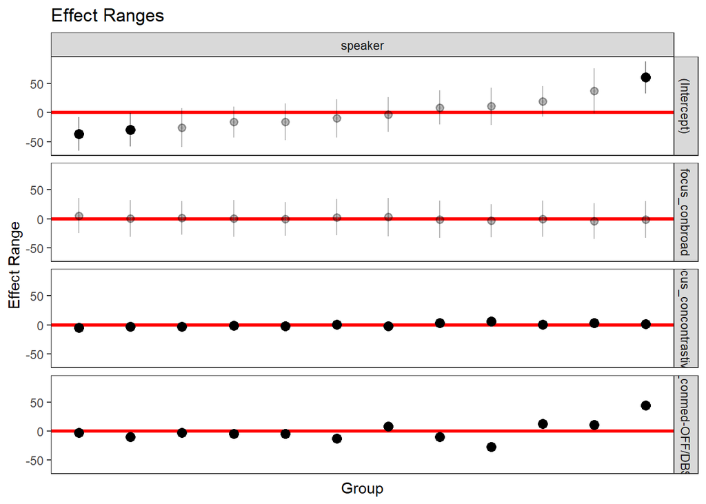

```r
randoms <- REsim(mdl)
plotREsim(randoms)
```

Plot estimated 95 % interval spans for the intercept of TB duration

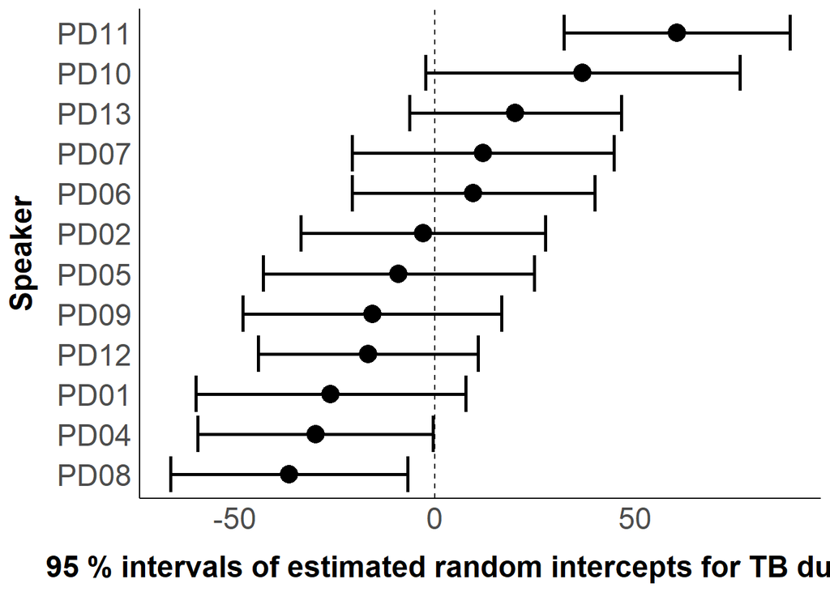

```r
random2 <- subset(randoms, term == "(Intercept)")

random2 %>%
  ggplot(aes(x = mean, xmin = mean-sd-sd, xmax = mean+sd+sd, y = reorder(groupID, mean))) +
  geom_vline(xintercept = 0, linetype = 'dashed') +
  geom_point(size = 5)+
  geom_errorbar(size = 1) +
  theme_classic()+
  xlab('95 % intervals of estimated random intercepts for TB duration') +
  ylab('Speaker')+
  theme(axis.title.y = element_text(face = 'bold', size = 18, margin = margin(r = 12)))+
  theme(axis.title.x = element_text(face = 'bold', size = 18, margin = margin(t = 12)))+
  theme(strip.text.x = element_text(size=18, face="bold"),
        strip.background = element_blank())+
  theme(axis.text.x = element_text(size = 18),
        axis.text.y = element_text(size = 18)) +
  theme(axis.ticks.x = element_blank(),
        axis.ticks.y = element_blank())+
  theme(legend.position = "top",
        legend.title = element_blank(),
        legend.text = element_text(size = 18))
```

Plot estimated 95 % interval spans for the slope of TB duration

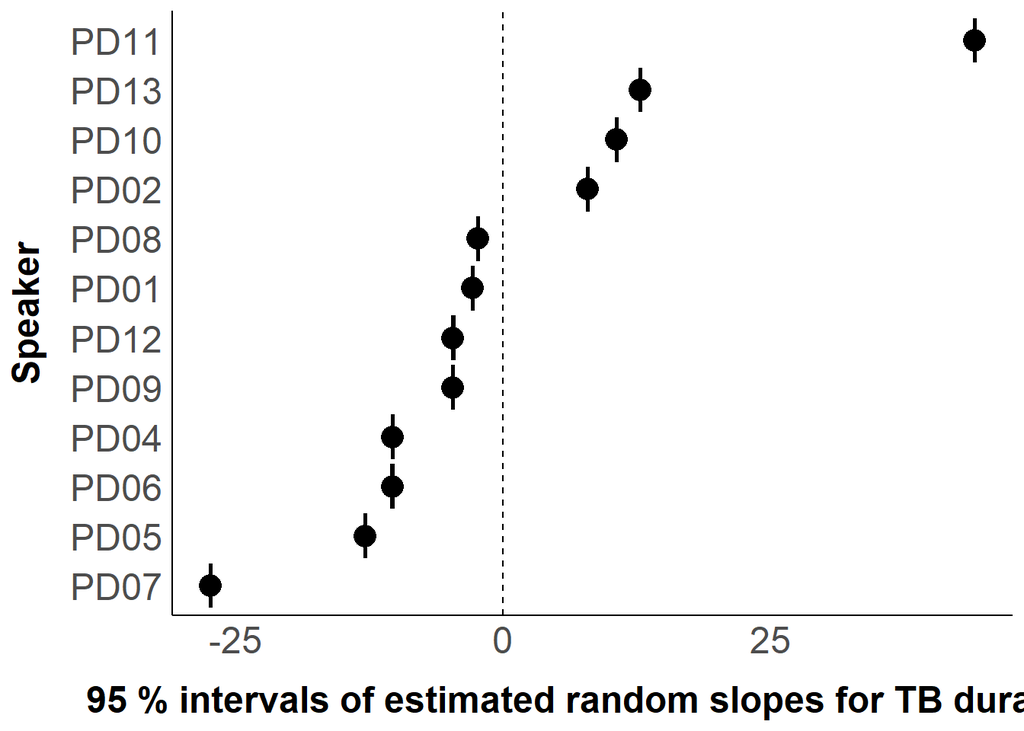

```r
random3 <- subset(randoms, term == "med_conmed-OFF/DBS-ON")

random3 %>%
  ggplot(aes(x = mean, xmin = mean-sd-sd, xmax = mean+sd+sd, y = reorder(groupID, mean))) +
  geom_vline(xintercept = 0, linetype = 'dashed') +
  geom_point(size = 5)+
  geom_errorbar(size = 1) +
  theme_classic()+
  xlab('95 % intervals of estimated random slopes for TB duration') +
  ylab('Speaker')+
  theme(axis.title.y = element_text(face = 'bold', size = 18, margin = margin(r = 12)))+
  theme(axis.title.x = element_text(face = 'bold', size = 18, margin = margin(t = 12)))+
  theme(strip.text.x = element_text(size=18, face="bold"),
        strip.background = element_blank())+
  theme(axis.text.x = element_text(size = 18),
        axis.text.y = element_text(size = 18)) +
  theme(axis.ticks.x = element_blank(),
        axis.ticks.y = element_blank())+
  theme(legend.position = "top",
        legend.title = element_blank(),
        legend.text = element_text(size = 18))
```

# Movement amplitude

Descriptive stats for reporting values in Section 8.2.3

```r
DISPL_stats <- data_red %>%
  group_by(med_con) %>%
  summarise(M = round(mean(disp_V1_abs),1),
            SD = round(sd(disp_V1_abs),1))
DISPL_stats
```

```
## # A tibble: 2 x 3
##   med_con             M    SD
##   <chr>           <dbl> <dbl>
## 1 med-OFF/DBS-OFF   6.8   4.4
## 2 med-OFF/DBS-ON    6.9   4.6
```

```r
DISPL_stats2 <- data_red %>%
  group_by(med_con, focus_con) %>%
  summarise(M = round(mean(disp_V1_abs),1),
            SD = round(sd(disp_V1_abs),1))
DISPL_stats2
```

```
## # A tibble: 6 x 4
## # Groups:   med_con [2]
##   med_con         focus_con       M    SD
##   <chr>           <chr>       <dbl> <dbl>
## 1 med-OFF/DBS-OFF background    6.5   4
## 2 med-OFF/DBS-OFF broad         6.9   4.5
## 3 med-OFF/DBS-OFF contrastive   7     4.7
## 4 med-OFF/DBS-ON  background    6.5   4.3
## 5 med-OFF/DBS-ON  broad         6.9   4.5
## 6 med-OFF/DBS-ON  contrastive   7.2   4.8
```

Plot tongue body movement amplitude

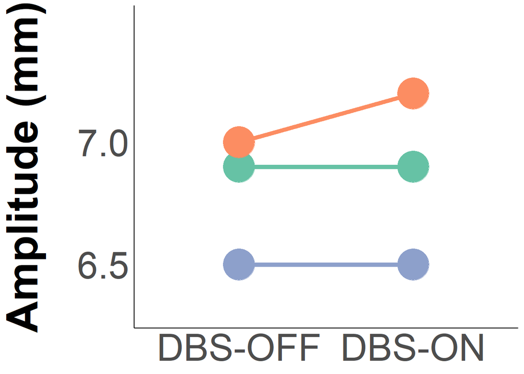

```r
DISPL_stats2 %>%
  ggplot(aes(x=med_con, y=M, group = focus_con, col=focus_con)) +
  geom_line(size = 2) +
  geom_point(size = 14)+
  theme_classic() +
  theme(legend.position = 'none')+
  theme(legend.title = element_blank(),
        legend.text = element_text(size = 36))+
  scale_color_manual(values = c("#8da0cb", "#66c2a5", "#fc8d62")) +
  coord_cartesian(ylim = c(6.3, 7.5)) +
  scale_y_continuous(breaks = seq(6.5, 7.0, 0.5)) +
  xlab(NULL) +
  scale_x_discrete(labels = c('DBS-OFF','DBS-ON'))+
  ylab("Amplitude (mm)")+
  theme(axis.title.y = element_text(face = 'bold', size = 42, margin = margin(r = 30)))+
  theme(strip.text.x = element_text(size=38, face="bold"),
        strip.background = element_blank())+
  theme(axis.text.x = element_text(size = 36),
        axis.text.y = element_text(size = 36)) +
  theme(axis.ticks.x = element_blank(),
        axis.ticks.y = element_blank())
```

Create linear mixed model to investigate disease effect on TB amplitude

```r
mdl2 <- lmer(disp_V1_abs ~ med_con + focus_con + vowel + cons + age  + (1 + focus_con+med_con|speaker), data_red, REML = FALSE)
```

Look at model summary

```r
summary(mdl2)
```

```
## Linear mixed model fit by maximum likelihood . t-tests use Satterthwaite's
##   method [lmerModLmerTest]
## Formula: disp_V1_abs ~ med_con + focus_con + vowel + cons + age + (1 +
##     focus_con + med_con | speaker)
##    Data: data_red
##
##      AIC      BIC   logLik deviance df.resid
##   3306.3   3402.2  -1632.2   3264.3      689
##
## Scaled residuals:
##     Min      1Q  Median      3Q     Max
## -3.0177 -0.7054 -0.0055  0.6785  3.4975
##
## Random effects:
##  Groups   Name                  Variance Std.Dev. Corr
##  speaker  (Intercept)           2.33435  1.5279
##           focus_conbroad        0.01799  0.1341   0.98
##           focus_concontrastive  0.02984  0.1727   0.81 0.91
##           med_conmed-OFF/DBS-ON 0.31490  0.5612   0.22 0.39 0.75
##  Residual                       5.42689  2.3296
## Number of obs: 710, groups:  speaker, 12
##
## Fixed effects:
##                         Estimate Std. Error         df t value Pr(>|t|)
## (Intercept)            12.200480   3.463063  12.569935   3.523  0.00393 **
## med_conmed-OFF/DBS-ON   0.042896   0.238736  12.200453   0.180  0.86035
## focus_conbroad          0.348668   0.217502 152.751353   1.603  0.11099
## focus_concontrastive    0.523580   0.219820  97.177927   2.382  0.01917 *
## vowele                 -7.549319   0.276775 687.692830 -27.276  < 2e-16 ***
## voweli                 -6.454764   0.275329 687.674059 -23.444  < 2e-16 ***
## vowelo                 -5.400334   0.279000 686.251070 -19.356  < 2e-16 ***
## vowelu                -10.309318   0.277041 686.535071 -37.212  < 2e-16 ***
## conslab                 0.573276   0.174881 686.234296   3.278  0.00110 **
## age                     0.000085   0.057624  12.417645   0.001  0.99885
## ---
## Signif. codes:  0 '***' 0.001 '**' 0.01 '*' 0.05 '.' 0.1 ' ' 1
##
## Correlation of Fixed Effects:
##             (Intr) m_-OFF fcs_cnb fcs_cnc vowele voweli vowelo vowelu conslb
## m_-OFF/DBS- -0.012
## focus_cnbrd -0.014  0.047
## fcs_cncntrs -0.018  0.118  0.514
## vowele      -0.052  0.009  0.002   0.009
## voweli      -0.050  0.007  0.008   0.011   0.507
## vowelo      -0.041 -0.002  0.005   0.011   0.498  0.501
## vowelu      -0.046  0.006  0.003   0.003   0.503  0.506  0.498
## conslab     -0.026  0.002  0.000   0.000  -0.004 -0.002 -0.002 -0.002
## age         -0.989  0.011  0.006   0.011   0.011  0.009  0.001  0.005  0.001
## optimizer (nloptwrap) convergence code: 0 (OK)
## boundary (singular) fit: see help('isSingular')
```

extracting fit statistics for reporting in text

```r
tab_model(mdl2)
```

|  | disp V 1 abs |  |  |
| --- | --- | --- | --- |
| Predictors | Estimates | CI | p |
| (Intercept) | 12.20 | 5.40 – 19.00 | **<0.001** |
| med con [med-OFF/DBS-ON] | 0.04 | -0.43 – 0.51 | 0.857 |
| focus con [broad] | 0.35 | -0.08 – 0.78 | 0.109 |
| focus con [contrastive] | 0.52 | 0.09 – 0.96 | **0.017** |
| vowel [e] | -7.55 | -8.09 – -7.01 | **<0.001** |
| vowel [i] | -6.45 | -7.00 – -5.91 | **<0.001** |
| vowel [o] | -5.40 | -5.95 – -4.85 | **<0.001** |
| vowel [u] | -10.31 | -10.85 – -9.77 | **<0.001** |
| cons [lab] | 0.57 | 0.23 – 0.92 | **0.001** |
| age | 0.00 | -0.11 – 0.11 | 0.999 |
| Random Effects |  |  |  |
| σ<sup>2</sup> | 5.43 |  |  |
| τ<sub>00</sub> <sub>speaker</sub> | 2.33 |  |  |
| τ<sub>11</sub> <sub>speaker.focus_conbroad</sub> | 0.02 |  |  |
| τ<sub>11</sub> <sub>speaker.focus_concontrastive</sub> | 0.03 |  |  |
| τ<sub>11</sub> <sub>speaker.med_conmed-OFF/DBS-ON</sub> | 0.31 |  |  |
| ρ<sub>01</sub> | 0.98 |  |  |
|  | 0.81 |  |  |
|  | 0.22 |  |  |
| N <sub>speaker</sub> | 12 |  |  |
| Observations | 710 |  |  |
| Marginal R<sup>2</sup> / Conditional R<sup>2</sup> | 0.681 / NA |  |  |

## Explore random effects with function REsim

Effects for individual levels are simulated  
Output: mean, median and sd of the random effect estimates

Plots estimated random effects for each participant  
95 % Intervals that do not overlap zero are bold

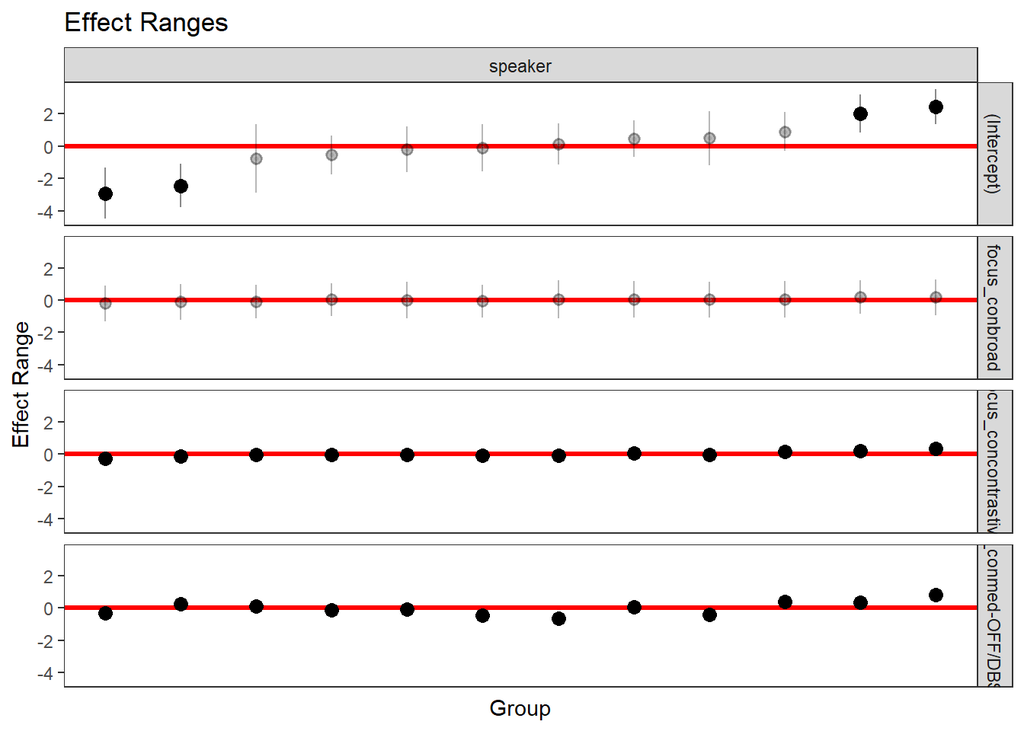

```r
randoms <- REsim(mdl2)
plotREsim(randoms)
```

Plot estimated 95 % interval spans for the intercept of TB amplitude

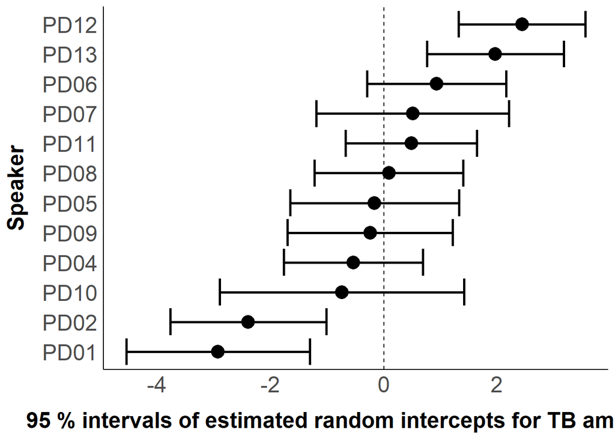

```r
random2 <- subset(randoms, term == "(Intercept)")

random2 %>%
  ggplot(aes(x = mean, xmin = mean-sd-sd, xmax = mean+sd+sd, y = reorder(groupID, mean))) +
  geom_vline(xintercept = 0, linetype = 'dashed') +
  geom_point(size = 5)+
  geom_errorbar(size = 1) +
  theme_classic()+
  xlab('95 % intervals of estimated random intercepts for TB amplitude') +
  ylab('Speaker')+
  theme(axis.title.y = element_text(face = 'bold', size = 18, margin = margin(r = 12)))+
  theme(axis.title.x = element_text(face = 'bold', size = 18, margin = margin(t = 12)))+
  theme(strip.text.x = element_text(size=18, face="bold"),
        strip.background = element_blank())+
  theme(axis.text.x = element_text(size = 18),
        axis.text.y = element_text(size = 18)) +
  theme(axis.ticks.x = element_blank(),
        axis.ticks.y = element_blank())+
  theme(legend.position = "top",
        legend.title = element_blank(),
        legend.text = element_text(size = 18))
```

Plot estimated 95 % interval spans for the slopes of TB amplitude

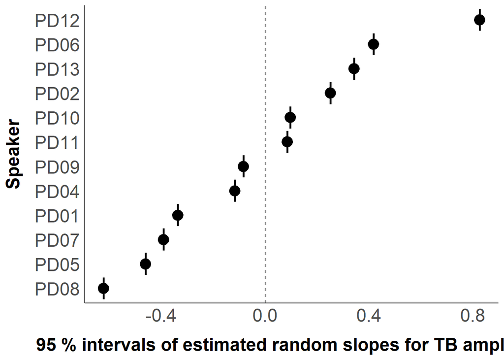

```r
random3 <- subset(randoms, term == "med_conmed-OFF/DBS-ON")

random3 %>%
  ggplot(aes(x = mean, xmin = mean-sd-sd, xmax = mean+sd+sd, y = reorder(groupID, mean))) +
  geom_vline(xintercept = 0, linetype = 'dashed') +
  geom_point(size = 5)+
  geom_errorbar(size = 1) +
  theme_classic()+
  xlab('95 % intervals of estimated random slopes for TB amplitude') +
  ylab('Speaker')+
  theme(axis.title.y = element_text(face = 'bold', size = 18, margin = margin(r = 12)))+
  theme(axis.title.x = element_text(face = 'bold', size = 18, margin = margin(t = 12)))+
  theme(strip.text.x = element_text(size=18, face="bold"),
        strip.background = element_blank())+
  theme(axis.text.x = element_text(size = 18),
        axis.text.y = element_text(size = 18)) +
  theme(axis.ticks.x = element_blank(),
        axis.ticks.y = element_blank())+
  theme(legend.position = "top",
        legend.title = element_blank(),
        legend.text = element_text(size = 18))
```

# Movement peak velocities

Descriptive stats for reporting values in Section 8.2.3

```r
PVEL_stats <- data_red %>%
  group_by(med_con) %>%
  summarise(M = round(mean(pvel_V1_abs)),
            SD = round(sd(pvel_V1_abs)))
PVEL_stats
```

```
## # A tibble: 2 x 3
##   med_con             M    SD
##   <chr>           <dbl> <dbl>
## 1 med-OFF/DBS-OFF    66    40
## 2 med-OFF/DBS-ON     65    39
```

```r
PVEL_stats2 <- data_red %>%
  group_by(med_con, focus_con) %>%
  summarise(M = round(mean(pvel_V1_abs)),
            SD = round(sd(pvel_V1_abs)))
PVEL_stats2
```

```
## # A tibble: 6 x 4
## # Groups:   med_con [2]
##   med_con         focus_con       M    SD
##   <chr>           <chr>       <dbl> <dbl>
## 1 med-OFF/DBS-OFF background     67    39
## 2 med-OFF/DBS-OFF broad          65    40
## 3 med-OFF/DBS-OFF contrastive    66    41
## 4 med-OFF/DBS-ON  background     66    38
## 5 med-OFF/DBS-ON  broad          65    40
## 6 med-OFF/DBS-ON  contrastive    65    39
```

Create linear mixed model to investigate disease effect on TB velocity

```r
mdl3 <- lmer(pvel_V1_abs ~ med_con + focus_con + vowel + cons + age  + (1 + focus_con+med_con|speaker), data_red, REML = FALSE)
```

Look at model summary

```r
summary(mdl3)
```

```
## Linear mixed model fit by maximum likelihood . t-tests use Satterthwaite's
##   method [lmerModLmerTest]
## Formula: pvel_V1_abs ~ med_con + focus_con + vowel + cons + age + (1 +
##     focus_con + med_con | speaker)
##    Data: data_red
##
##      AIC      BIC   logLik deviance df.resid
##   6453.1   6549.0  -3205.6   6411.1      689
##
## Scaled residuals:
##     Min      1Q  Median      3Q     Max
## -3.7918 -0.5563 -0.0107  0.6330  3.5754
##
## Random effects:
##  Groups   Name                  Variance Std.Dev. Corr
##  speaker  (Intercept)           327.609  18.100
##           focus_conbroad          1.121   1.059   -0.28
##           focus_concontrastive   10.133   3.183   -0.12  0.99
##           med_conmed-OFF/DBS-ON   6.033   2.456   -0.19  0.99  1.00
##  Residual                       456.112  21.357
## Number of obs: 710, groups:  speaker, 12
##
## Fixed effects:
##                       Estimate Std. Error       df t value Pr(>|t|)
## (Intercept)           117.0101    37.7944  12.1578   3.096  0.00913 **
## med_conmed-OFF/DBS-ON  -1.0055     1.7565  24.1907  -0.572  0.57231
## focus_conbroad         -1.6821     1.9857 130.4674  -0.847  0.39850
## focus_concontrastive   -0.9380     2.1674  20.8805  -0.433  0.66962
## vowele                -61.2788     2.5372 688.0890 -24.153  < 2e-16 ***
## voweli                -45.2035     2.5239 688.0848 -17.910  < 2e-16 ***
## vowelo                -39.7578     2.5578 686.5427 -15.544  < 2e-16 ***
## vowelu                -80.7294     2.5398 686.8017 -31.786  < 2e-16 ***
## conslab                13.8227     1.6032 686.3721   8.622  < 2e-16 ***
## age                    -0.1958     0.6293  12.0338  -0.311  0.76101
## ---
## Signif. codes:  0 '***' 0.001 '**' 0.01 '*' 0.05 '.' 0.1 ' ' 1
##
## Correlation of Fixed Effects:
##             (Intr) m_-OFF fcs_cnb fcs_cnc vowele voweli vowelo vowelu conslb
## m_-OFF/DBS- -0.035
## focus_cnbrd -0.031  0.062
## fcs_cncntrs -0.034  0.175  0.510
## vowele      -0.039  0.011  0.003   0.008
## voweli      -0.038  0.009  0.008   0.011   0.507
## vowelo      -0.034 -0.002  0.005   0.010   0.499  0.501
## vowelu      -0.036  0.007  0.003   0.003   0.503  0.506  0.498
## conslab     -0.022  0.003  0.000   0.000  -0.004 -0.002 -0.002 -0.002
## age         -0.988  0.004 -0.001   0.003   0.005  0.003  0.000  0.002  0.001
## optimizer (nloptwrap) convergence code: 0 (OK)
## boundary (singular) fit: see help('isSingular')
```

extracting fit statistics for reporting in text

```r
tab_model(mdl3)
```

|  | pvel V 1 abs |  |  |
| --- | --- | --- | --- |
| Predictors | Estimates | CI | p |
| (Intercept) | 117.01 | 42.80 – 191.22 | **0.002** |
| med con [med-OFF/DBS-ON] | -1.01 | -4.45 – 2.44 | 0.567 |
| focus con [broad] | -1.68 | -5.58 – 2.22 | 0.397 |
| focus con [contrastive] | -0.94 | -5.19 – 3.32 | 0.665 |
| vowel [e] | -61.28 | -66.26 – -56.30 | **<0.001** |
| vowel [i] | -45.20 | -50.16 – -40.25 | **<0.001** |
| vowel [o] | -39.76 | -44.78 – -34.74 | **<0.001** |
| vowel [u] | -80.73 | -85.72 – -75.74 | **<0.001** |
| cons [lab] | 13.82 | 10.67 – 16.97 | **<0.001** |
| age | -0.20 | -1.43 – 1.04 | 0.756 |
| Random Effects |  |  |  |
| σ<sup>2</sup> | 456.11 |  |  |
| τ<sub>00</sub> <sub>speaker</sub> | 327.61 |  |  |
| τ<sub>11</sub> <sub>speaker.focus_conbroad</sub> | 1.12 |  |  |
| τ<sub>11</sub> <sub>speaker.focus_concontrastive</sub> | 10.13 |  |  |
| τ<sub>11</sub> <sub>speaker.med_conmed-OFF/DBS-ON</sub> | 6.03 |  |  |
| ρ<sub>01</sub> | -0.28 |  |  |
|  | -0.12 |  |  |
|  | -0.19 |  |  |
| N <sub>speaker</sub> | 12 |  |  |
| Observations | 710 |  |  |
| Marginal R<sup>2</sup> / Conditional R<sup>2</sup> | 0.626 / NA |  |  |

Explore random effects with function REsim

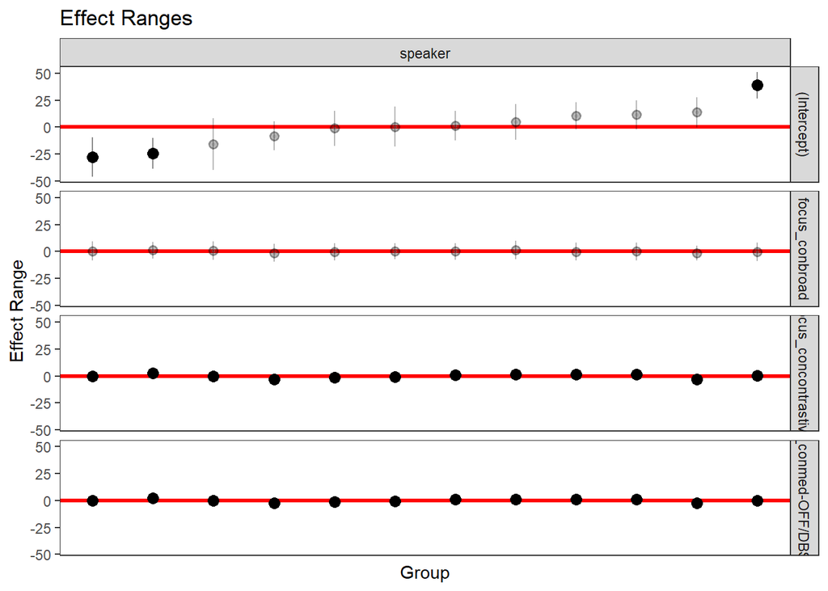

```r
randoms <- REsim(mdl3)
plotREsim(randoms)
```

Plot estimated 95 % interval spans for the intercept of TB velocity

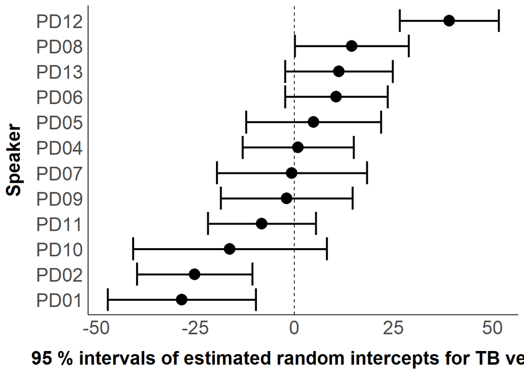

```r
random2 <- subset(randoms, term == "(Intercept)")

random2 %>%
  ggplot(aes(x = mean, xmin = mean-sd-sd, xmax = mean+sd+sd, y = reorder(groupID, mean))) +
  geom_vline(xintercept = 0, linetype = 'dashed') +
  geom_point(size = 5)+
  geom_errorbar(size = 1) +
  theme_classic()+
  xlab('95 % intervals of estimated random intercepts for TB velocity') +
  ylab('Speaker')+
  theme(axis.title.y = element_text(face = 'bold', size = 18, margin = margin(r = 12)))+
  theme(axis.title.x = element_text(face = 'bold', size = 18, margin = margin(t = 12)))+
  theme(strip.text.x = element_text(size=18, face="bold"),
        strip.background = element_blank())+
  theme(axis.text.x = element_text(size = 18),
        axis.text.y = element_text(size = 18)) +
  theme(axis.ticks.x = element_blank(),
        axis.ticks.y = element_blank())+
  theme(legend.position = "top",
        legend.title = element_blank(),
        legend.text = element_text(size = 18))
```

[figure not shown]

```r
random3 <- subset(randoms, term == "med_conmed-ON")

random3 %>%
  ggplot(aes(x = mean, xmin = mean-sd-sd, xmax = mean+sd+sd, y = reorder(groupID, mean))) +
  geom_vline(xintercept = 0, linetype = 'dashed') +
  geom_point(size = 5)+
  geom_errorbar(size = 1) +
  theme_classic()+
  xlab('95 % intervals of estimated random slopes for TB velocity') +
  ylab('Speaker')+
  theme(axis.title.y = element_text(face = 'bold', size = 18, margin = margin(r = 12)))+
  theme(axis.title.x = element_text(face = 'bold', size = 18, margin = margin(t = 12)))+
  theme(strip.text.x = element_text(size=18, face="bold"),
        strip.background = element_blank())+
  theme(axis.text.x = element_text(size = 18),
        axis.text.y = element_text(size = 18)) +
  theme(axis.ticks.x = element_blank(),
        axis.ticks.y = element_blank())+
  theme(legend.position = "top",
        legend.title = element_blank(),
        legend.text = element_text(size = 18))
```

[output not shown]

# Movement Profiles

Descriptive stats for reporting values in Table 8.2

Subset for production of vowels /a/ and /i/

```r
data_red_i_a <-  filter(data_red, vowel %in% c('i', 'a'))
```

Acceleration phase

```r
ACC_stats <- data_red_i_a %>%
  group_by(med_con) %>%
  summarise(M = round(mean(acc_V1)),
            SD = round(sd(acc_V1)))
ACC_stats
```

```
## # A tibble: 2 x 3
##   med_con             M    SD
##   <chr>           <dbl> <dbl>
## 1 med-OFF/DBS-OFF    97    39
## 2 med-OFF/DBS-ON    100    41
```

```r
ACC_stats2 <- data_red_i_a %>%
  group_by(med_con, focus_con) %>%
  summarise(M = round(mean(acc_V1)),
            SD = round(sd(acc_V1)))
ACC_stats2
```

```
## # A tibble: 6 x 4
## # Groups:   med_con [2]
##   med_con         focus_con       M    SD
##   <chr>           <chr>       <dbl> <dbl>
## 1 med-OFF/DBS-OFF background     95    40
## 2 med-OFF/DBS-OFF broad         100    39
## 3 med-OFF/DBS-OFF contrastive    97    37
## 4 med-OFF/DBS-ON  background     98    37
## 5 med-OFF/DBS-ON  broad         100    44
## 6 med-OFF/DBS-ON  contrastive   102    42
```

Deceleration phase

```r
DEC_stats <- data_red_i_a %>%
  group_by(med_con) %>%
  summarise(M = round(mean(dec_V1)),
            SD = round(sd(dec_V1)))
DEC_stats
```

```
## # A tibble: 2 x 3
##   med_con             M    SD
##   <chr>           <dbl> <dbl>
## 1 med-OFF/DBS-OFF   105    29
## 2 med-OFF/DBS-ON    105    38
```

```r
DEC_stats2 <- data_red_i_a %>%
  group_by(med_con, focus_con) %>%
  summarise(M = round(mean(dec_V1)),
            SD = round(sd(dec_V1)))
DEC_stats2
```

```
## # A tibble: 6 x 4
## # Groups:   med_con [2]
##   med_con         focus_con       M    SD
##   <chr>           <chr>       <dbl> <dbl>
## 1 med-OFF/DBS-OFF background     97    25
## 2 med-OFF/DBS-OFF broad         107    29
## 3 med-OFF/DBS-OFF contrastive   111    30
## 4 med-OFF/DBS-ON  background     99    31
## 5 med-OFF/DBS-ON  broad         107    39
## 6 med-OFF/DBS-ON  contrastive   110    42
```

Symmetry profile

```r
SYMM_stats <- data_red_i_a %>%
  group_by(med_con) %>%
  summarise(M = round(mean(symmetry_V1),1),
            SD = round(sd(symmetry_V1),1))
SYMM_stats
```

```
## # A tibble: 2 x 3
##   med_con             M    SD
##   <chr>           <dbl> <dbl>
## 1 med-OFF/DBS-OFF   1.3   0.7
## 2 med-OFF/DBS-ON    1.2   0.7
```

```r
SYMM_stats2 <- data_red_i_a %>%
  group_by(med_con, focus_con) %>%
  summarise(M = round(mean(symmetry_V1),1),
            SD = round(sd(symmetry_V1),1))
SYMM_stats2
```

```
## # A tibble: 6 x 4
## # Groups:   med_con [2]
##   med_con         focus_con       M    SD
##   <chr>           <chr>       <dbl> <dbl>
## 1 med-OFF/DBS-OFF background    1.2   0.6
## 2 med-OFF/DBS-OFF broad         1.3   0.7
## 3 med-OFF/DBS-OFF contrastive   1.3   0.7
## 4 med-OFF/DBS-ON  background    1.2   0.7
## 5 med-OFF/DBS-ON  broad         1.3   0.8
## 6 med-OFF/DBS-ON  contrastive   1.3   0.7
```

Stiffness

```r
STIFF_stats <- data_red_i_a %>%
  group_by(med_con) %>%
  summarise(M = round(mean(stiffness_V1_abs),1),
            SD = round(sd(stiffness_V1_abs),1))
STIFF_stats
```

```
## # A tibble: 2 x 3
##   med_con             M    SD
##   <chr>           <dbl> <dbl>
## 1 med-OFF/DBS-OFF   9.6   2.5
## 2 med-OFF/DBS-ON    9.8   2.7
```

```r
STIFF_stats2 <- data_red_i_a %>%
  group_by(med_con, focus_con) %>%
  summarise(M = round(mean(stiffness_V1_abs),1),
            SD = round(sd(stiffness_V1_abs),1))
STIFF_stats2
```

```
## # A tibble: 6 x 4
## # Groups:   med_con [2]
##   med_con         focus_con       M    SD
##   <chr>           <chr>       <dbl> <dbl>
## 1 med-OFF/DBS-OFF background   10.1   2.5
## 2 med-OFF/DBS-OFF broad         9.2   2.3
## 3 med-OFF/DBS-OFF contrastive   9.5   2.6
## 4 med-OFF/DBS-ON  background   10.1   2.4
## 5 med-OFF/DBS-ON  broad         9.9   3
## 6 med-OFF/DBS-ON  contrastive   9.5   2.8
```

# Timing pattern

```r
ONS_avgs <- data_red %>%
  group_by(med_con) %>%
  summarise(M = round(mean(onsC1_to_onsV1)),
            SD = round(sd(onsC1_to_onsV1)))
ONS_avgs
```

```
## # A tibble: 2 x 3
##   med_con             M    SD
##   <chr>           <dbl> <dbl>
## 1 med-OFF/DBS-OFF    31    38
## 2 med-OFF/DBS-ON     24    34
```

```r
TARG_avgs <- data_red %>%
  group_by(med_con) %>%
  summarise(M = round(mean(targC1_to_targV1)),
            SD = round(sd(targC1_to_targV1)))
TARG_avgs
```

```
## # A tibble: 2 x 3
##   med_con             M    SD
##   <chr>           <dbl> <dbl>
## 1 med-OFF/DBS-OFF   125    34
## 2 med-OFF/DBS-ON    121    36
```

```r
OnsAlign_avgs <- data_red %>%
  group_by(med_con) %>%
  summarise(M = round(mean(onsV1.syll.dur),2)*100,
            SD = round(sd(onsV1.syll.dur),2)*100)
OnsAlign_avgs
```

```
## # A tibble: 2 x 3
##   med_con             M    SD
##   <chr>           <dbl> <dbl>
## 1 med-OFF/DBS-OFF   -16    15
## 2 med-OFF/DBS-ON    -18    14
```

```r
TargAlign_avgs <- data_red %>%
  group_by(med_con) %>%
  summarise(M = round(mean(targV1.syll.dur),2)*100,
            SD = round(sd(targV1.syll.dur),2)*100)
TargAlign_avgs
```

```
## # A tibble: 2 x 3
##   med_con             M    SD
##   <chr>           <dbl> <dbl>
## 1 med-OFF/DBS-OFF    68    10
## 2 med-OFF/DBS-ON     68     9
```

Statistical analysis for timing patterns

create model for onset to onset interval

```r
mdl4 <- lmer(onsC1_to_onsV1 ~ med_con + focus_con + vowel + cons + age  + (1 + focus_con+med_con|speaker), data_red, REML = FALSE)
```

Look at model

```r
summary(mdl4)
```

```
## Linear mixed model fit by maximum likelihood . t-tests use Satterthwaite's
##   method [lmerModLmerTest]
## Formula: onsC1_to_onsV1 ~ med_con + focus_con + vowel + cons + age + (1 +
##     focus_con + med_con | speaker)
##    Data: data_red
##
##      AIC      BIC   logLik deviance df.resid
##   6935.8   7031.7  -3446.9   6893.8      689
##
## Scaled residuals:
##     Min      1Q  Median      3Q     Max
## -2.9740 -0.6215  0.0000  0.6323  4.0870
##
## Random effects:
##  Groups   Name                  Variance Std.Dev. Corr
##  speaker  (Intercept)           191.9570 13.8549
##           focus_conbroad          9.3942  3.0650   1.00
##           focus_concontrastive    0.1637  0.4046  -1.00 -1.00
##           med_conmed-OFF/DBS-ON  52.2530  7.2286  -1.00 -1.00  1.00
##  Residual                       928.2020 30.4664
## Number of obs: 710, groups:  speaker, 12
##
## Fixed effects:
##                        Estimate Std. Error        df t value Pr(>|t|)
## (Intercept)            12.81408   18.94635  17.72420   0.676   0.5076
## med_conmed-OFF/DBS-ON  -7.17938    3.10119  14.16315  -2.315   0.0361 *
## focus_conbroad          2.54279    2.93596  58.34536   0.866   0.3900
## focus_concontrastive    2.81547    2.80210 575.55703   1.005   0.3154
## vowele                 15.94499    3.61992 695.77833   4.405 1.23e-05 ***
## voweli                  1.05074    3.60123 695.94603   0.292   0.7705
## vowelo                  1.61747    3.64871 695.11712   0.443   0.6577
## vowelu                 28.81421    3.62319 695.24849   7.953 7.40e-15 ***
## conslab                21.06108    2.28702 695.12693   9.209  < 2e-16 ***
## age                    -0.05213    0.30690  16.10458  -0.170   0.8672
## ---
## Signif. codes:  0 '***' 0.001 '**' 0.01 '*' 0.05 '.' 0.1 ' ' 1
##
## Correlation of Fixed Effects:
##             (Intr) m_-OFF fcs_cnb fcs_cnc vowele voweli vowelo vowelu conslb
## m_-OFF/DBS- -0.178
## focus_cnbrd -0.019 -0.204
## fcs_cncntrs -0.088  0.031  0.461
## vowele      -0.093  0.009  0.002   0.009
## voweli      -0.088  0.008  0.007   0.012   0.507
## vowelo      -0.098 -0.002  0.005   0.011   0.498  0.501
## vowelu      -0.096  0.006  0.002   0.003   0.503  0.506  0.498
## conslab     -0.059  0.002  0.000   0.000  -0.004 -0.002 -0.002 -0.002
## age         -0.960 -0.011  0.013   0.004  -0.004 -0.011  0.002 -0.001 -0.001
## optimizer (nloptwrap) convergence code: 0 (OK)
## boundary (singular) fit: see help('isSingular')
```

Extracting fit statistics for reporting in text

```r
tab_model(mdl4)
```

|  | ons C 1 to ons V 1 |  |  |
| --- | --- | --- | --- |
| Predictors | Estimates | CI | p |
| (Intercept) | 12.81 | -24.39 – 50.01 | 0.499 |
| med con [med-OFF/DBS-ON] | -7.18 | -13.27 – -1.09 | **0.021** |
| focus con [broad] | 2.54 | -3.22 – 8.31 | 0.387 |
| focus con [contrastive] | 2.82 | -2.69 – 8.32 | 0.315 |
| vowel [e] | 15.94 | 8.84 – 23.05 | **<0.001** |
| vowel [i] | 1.05 | -6.02 – 8.12 | 0.771 |
| vowel [o] | 1.62 | -5.55 – 8.78 | 0.658 |
| vowel [u] | 28.81 | 21.70 – 35.93 | **<0.001** |
| cons [lab] | 21.06 | 16.57 – 25.55 | **<0.001** |
| age | -0.05 | -0.65 – 0.55 | 0.865 |
| Random Effects |  |  |  |
| σ<sup>2</sup> | 928.20 |  |  |
| τ<sub>00</sub> <sub>speaker</sub> | 191.96 |  |  |
| τ<sub>11</sub> <sub>speaker.focus_conbroad</sub> | 9.39 |  |  |
| τ<sub>11</sub> <sub>speaker.focus_concontrastive</sub> | 0.16 |  |  |
| τ<sub>11</sub> <sub>speaker.med_conmed-OFF/DBS-ON</sub> | 52.25 |  |  |
| ρ<sub>01</sub> | 1.00 |  |  |
|  | -1.00 |  |  |
|  | -1.00 |  |  |
| N <sub>speaker</sub> | 12 |  |  |
| Observations | 710 |  |  |
| Marginal R<sup>2</sup> / Conditional R<sup>2</sup> | 0.216 / NA |  |  |

create model for target to target interval

```r
mdl5 <- lmer(targC1_to_targV1 ~ med_con + focus_con + vowel + cons + age  + (1 + focus_con+med_con|speaker), data_red, REML = FALSE)
```

Look at model

```r
summary(mdl5)
```

```
## Linear mixed model fit by maximum likelihood . t-tests use Satterthwaite's
##   method [lmerModLmerTest]
## Formula: targC1_to_targV1 ~ med_con + focus_con + vowel + cons + age +
##     (1 + focus_con + med_con | speaker)
##    Data: data_red
##
##      AIC      BIC   logLik deviance df.resid
##   6735.7   6831.6  -3346.9   6693.7      689
##
## Scaled residuals:
##     Min      1Q  Median      3Q     Max
## -3.9687 -0.6564 -0.0335  0.6101  3.2045
##
## Random effects:
##  Groups   Name                  Variance  Std.Dev. Corr
##  speaker  (Intercept)           303.63071 17.4250
##           focus_conbroad         10.54837  3.2478  0.02
##           focus_concontrastive    0.01445  0.1202  0.87 0.50
##           med_conmed-OFF/DBS-ON  71.57680  8.4603  0.33 0.95 0.75
##  Residual                       675.99180 25.9998
## Number of obs: 710, groups:  speaker, 12
##
## Fixed effects:
##                       Estimate Std. Error       df t value Pr(>|t|)
## (Intercept)           117.0146    37.8814  12.6394   3.089  0.00888 **
## med_conmed-OFF/DBS-ON  -4.7550     3.1296  12.5248  -1.519  0.15350
## focus_conbroad          7.6541     2.5662  34.4199   2.983  0.00522 **
## focus_concontrastive   14.5561     2.3897 668.4116   6.091 1.89e-09 ***
## vowele                -19.4830     3.0889 686.9080  -6.308 5.08e-10 ***
## voweli                -35.3504     3.0726 686.8417 -11.505  < 2e-16 ***
## vowelo                -15.3077     3.1140 686.3183  -4.916 1.11e-06 ***
## vowelu                -16.1636     3.0920 686.3306  -5.228 2.28e-07 ***
## conslab                -4.6061     1.9518 686.1936  -2.360  0.01856 *
## age                     0.3523     0.6298  12.4486   0.559  0.58582
## ---
## Signif. codes:  0 '***' 0.001 '**' 0.01 '*' 0.05 '.' 0.1 ' ' 1
##
## Correlation of Fixed Effects:
##             (Intr) m_-OFF fcs_cnb fcs_cnc vowele voweli vowelo vowelu conslb
## m_-OFF/DBS-  0.004
## focus_cnbrd -0.026  0.271
## fcs_cncntrs -0.037  0.011  0.466
## vowele      -0.055  0.007  0.003   0.009
## voweli      -0.055  0.006  0.008   0.012   0.507
## vowelo      -0.039 -0.002  0.005   0.011   0.498  0.501
## vowelu      -0.047  0.005  0.003   0.003   0.503  0.506  0.498
## conslab     -0.027  0.002  0.000   0.000  -0.004 -0.002 -0.002 -0.002
## age         -0.988  0.013 -0.003   0.007   0.014  0.013 -0.002  0.006  0.002
## optimizer (nloptwrap) convergence code: 0 (OK)
## boundary (singular) fit: see help('isSingular')
```

Extracting fit statistics for reporting in text

```r
tab_model(mdl5)
```

|  | targ C 1 to targ V 1 |  |  |
| --- | --- | --- | --- |
| Predictors | Estimates | CI | p |
| (Intercept) | 117.01 | 42.64 – 191.39 | **0.002** |
| med con [med-OFF/DBS-ON] | -4.76 | -10.90 – 1.39 | 0.129 |
| focus con [broad] | 7.65 | 2.62 – 12.69 | **0.003** |
| focus con [contrastive] | 14.56 | 9.86 – 19.25 | **<0.001** |
| vowel [e] | -19.48 | -25.55 – -13.42 | **<0.001** |
| vowel [i] | -35.35 | -41.38 – -29.32 | **<0.001** |
| vowel [o] | -15.31 | -21.42 – -9.19 | **<0.001** |
| vowel [u] | -16.16 | -22.23 – -10.09 | **<0.001** |
| cons [lab] | -4.61 | -8.44 – -0.77 | **0.019** |
| age | 0.35 | -0.88 – 1.59 | 0.576 |
| Random Effects |  |  |  |
| σ<sup>2</sup> | 675.99 |  |  |
| τ<sub>00</sub> <sub>speaker</sub> | 303.63 |  |  |
| τ<sub>11</sub> <sub>speaker.focus_conbroad</sub> | 10.55 |  |  |
| τ<sub>11</sub> <sub>speaker.focus_concontrastive</sub> | 0.01 |  |  |
| τ<sub>11</sub> <sub>speaker.med_conmed-OFF/DBS-ON</sub> | 71.58 |  |  |
| ρ<sub>01</sub> | 0.02 |  |  |
|  | 0.87 |  |  |
|  | 0.33 |  |  |
| N <sub>speaker</sub> | 12 |  |  |
| Observations | 710 |  |  |
| Marginal R<sup>2</sup> / Conditional R<sup>2</sup> | 0.215 / NA |  |  |

create model for onset alignment

```r
mdl6 <- lmer(onsV1.syll.dur ~ med_con + focus_con + vowel + cons + age  + (1 + focus_con+med_con|speaker), data_red, REML = FALSE)
```

Look at model

```r
summary(mdl6)
```

```
## Linear mixed model fit by maximum likelihood . t-tests use Satterthwaite's
##   method [lmerModLmerTest]
## Formula: onsV1.syll.dur ~ med_con + focus_con + vowel + cons + age + (1 +
##     focus_con + med_con | speaker)
##    Data: data_red
##
##      AIC      BIC   logLik deviance df.resid
##   -858.3   -762.4    450.1   -900.3      689
##
## Scaled residuals:
##     Min      1Q  Median      3Q     Max
## -3.3165 -0.6364  0.0914  0.6670  3.2885
##
## Random effects:
##  Groups   Name                  Variance  Std.Dev. Corr
##  speaker  (Intercept)           1.396e-03 0.037367
##           focus_conbroad        3.885e-06 0.001971  1.00
##           focus_concontrastive  3.040e-05 0.005514 -0.98 -0.98
##           med_conmed-OFF/DBS-ON 1.659e-04 0.012880 -0.97 -0.97  0.90
##  Residual                       1.606e-02 0.126735
## Number of obs: 710, groups:  speaker, 12
##
## Fixed effects:
##                         Estimate Std. Error         df t value Pr(>|t|)
## (Intercept)            -0.282100   0.068918  14.074169  -4.093  0.00109 **
## med_conmed-OFF/DBS-ON  -0.016734   0.010234  12.871049  -1.635  0.12623
## focus_conbroad          0.011391   0.011657 529.570851   0.977  0.32893
## focus_concontrastive    0.026503   0.011754 210.864046   2.255  0.02518 *
## vowele                  0.042394   0.015054 687.076874   2.816  0.00500 **
## voweli                 -0.044716   0.014976 687.031136  -2.986  0.00293 **
## vowelo                  0.007464   0.015178 686.078538   0.492  0.62305
## vowelu                  0.098395   0.015071 685.923291   6.529 1.29e-10 ***
## conslab                 0.081276   0.009513 685.821835   8.543  < 2e-16 ***
## age                     0.000826   0.001119  12.617468   0.738  0.47406
## ---
## Signif. codes:  0 '***' 0.001 '**' 0.01 '*' 0.05 '.' 0.1 ' ' 1
##
## Correlation of Fixed Effects:
##             (Intr) m_-OFF fcs_cnb fcs_cnc vowele voweli vowelo vowelu conslb
## m_-OFF/DBS- -0.124
## focus_cnbrd -0.080 -0.018
## fcs_cncntrs -0.111  0.048  0.486
## vowele      -0.117  0.011  0.002   0.009
## voweli      -0.113  0.009  0.008   0.011   0.507
## vowelo      -0.109 -0.003  0.006   0.011   0.498  0.501
## vowelu      -0.114  0.007  0.003   0.003   0.503  0.506  0.498
## conslab     -0.070  0.003  0.000   0.000  -0.004 -0.002 -0.002 -0.002
## age         -0.965  0.001  0.003   0.005   0.006  0.000  0.000  0.003  0.001
## optimizer (nloptwrap) convergence code: 0 (OK)
## boundary (singular) fit: see help('isSingular')
```

Extracting fit statistics for reporting in text

```r
tab_model(mdl6)
```

|  | ons V 1.syll dur |  |  |
| --- | --- | --- | --- |
| Predictors | Estimates | CI | p |
| (Intercept) | -0.28 | -0.42 – -0.15 | **<0.001** |
| med con [med-OFF/DBS-ON] | -0.02 | -0.04 – 0.00 | 0.102 |
| focus con [broad] | 0.01 | -0.01 – 0.03 | 0.329 |
| focus con [contrastive] | 0.03 | 0.00 – 0.05 | **0.024** |
| vowel [e] | 0.04 | 0.01 – 0.07 | **0.005** |
| vowel [i] | -0.04 | -0.07 – -0.02 | **0.003** |
| vowel [o] | 0.01 | -0.02 – 0.04 | 0.623 |
| vowel [u] | 0.10 | 0.07 – 0.13 | **<0.001** |
| cons [lab] | 0.08 | 0.06 – 0.10 | **<0.001** |
| age | 0.00 | -0.00 – 0.00 | 0.461 |
| Random Effects |  |  |  |
| σ<sup>2</sup> | 0.02 |  |  |
| τ<sub>00</sub> <sub>speaker</sub> | 0.00 |  |  |
| τ<sub>11</sub> <sub>speaker.focus_conbroad</sub> | 0.00 |  |  |
| τ<sub>11</sub> <sub>speaker.focus_concontrastive</sub> | 0.00 |  |  |
| τ<sub>11</sub> <sub>speaker.med_conmed-OFF/DBS-ON</sub> | 0.00 |  |  |
| ρ<sub>01</sub> | 1.00 |  |  |
|  | -0.98 |  |  |
|  | -0.97 |  |  |
| N <sub>speaker</sub> | 12 |  |  |
| Observations | 710 |  |  |
| Marginal R<sup>2</sup> / Conditional R<sup>2</sup> | 0.207 / NA |  |  |

create model for target alignment

```r
mdl7 <- lmer(targV1.syll.dur ~ med_con + focus_con + vowel + cons + age + (1 + focus_con+med_con|speaker), data_red, REML = FALSE)
```

Look at model

```r
summary(mdl7)
```

```
## Linear mixed model fit by maximum likelihood . t-tests use Satterthwaite's
##   method [lmerModLmerTest]
## Formula: targV1.syll.dur ~ med_con + focus_con + vowel + cons + age +
##     (1 + focus_con + med_con | speaker)
##    Data: data_red
##
##      AIC      BIC   logLik deviance df.resid
##  -1385.3  -1289.4    713.6  -1427.3      689
##
## Scaled residuals:
##     Min      1Q  Median      3Q     Max
## -2.7885 -0.6533  0.0365  0.5867  4.8916
##
## Random effects:
##  Groups   Name                  Variance  Std.Dev. Corr
##  speaker  (Intercept)           0.0008660 0.02943
##           focus_conbroad        0.0002072 0.01439  -0.92
##           focus_concontrastive  0.0001033 0.01016  -0.97  0.81
##           med_conmed-OFF/DBS-ON 0.0001045 0.01022  -0.94  1.00  0.84
##  Residual                       0.0076570 0.08750
## Number of obs: 710, groups:  speaker, 12
##
## Fixed effects:
##                         Estimate Std. Error         df t value Pr(>|t|)
## (Intercept)            6.535e-01  4.088e-02  1.701e+01  15.987 1.11e-11 ***
## med_conmed-OFF/DBS-ON -7.195e-03  7.213e-03  3.147e+01  -0.998    0.326
## focus_conbroad         2.084e-03  9.051e-03  2.089e+01   0.230    0.820
## focus_concontrastive   4.337e-03  8.561e-03  4.027e+01   0.507    0.615
## vowele                 5.524e-02  1.039e-02  6.866e+02   5.315 1.45e-07 ***
## voweli                 5.123e-02  1.034e-02  6.865e+02   4.955 9.11e-07 ***
## vowelo                -1.401e-02  1.048e-02  6.862e+02  -1.337    0.182
## vowelu                 6.320e-02  1.041e-02  6.861e+02   6.074 2.07e-09 ***
## conslab               -2.630e-02  6.569e-03  6.860e+02  -4.004 6.92e-05 ***
## age                    1.731e-04  6.509e-04  1.420e+01   0.266    0.794
## ---
## Signif. codes:  0 '***' 0.001 '**' 0.01 '*' 0.05 '.' 0.1 ' ' 1
##
## Correlation of Fixed Effects:
##             (Intr) m_-OFF fcs_cnb fcs_cnc vowele voweli vowelo vowelu conslb
## m_-OFF/DBS- -0.164
## focus_cnbrd -0.166  0.188
## fcs_cncntrs -0.164  0.122  0.542
## vowele      -0.140  0.010  0.003   0.009
## voweli      -0.137  0.008  0.007   0.011   0.507
## vowelo      -0.126 -0.002  0.005   0.010   0.499  0.501
## vowelu      -0.135  0.007  0.003   0.003   0.503  0.506  0.498
## conslab     -0.083  0.003  0.000   0.000  -0.004 -0.002 -0.002 -0.002
## age         -0.947  0.007 -0.011   0.000   0.011  0.007 -0.001  0.006  0.004
## optimizer (nloptwrap) convergence code: 0 (OK)
## boundary (singular) fit: see help('isSingular')
```

Extracting fit statistics for reporting in text

```r
tab_model(mdl7)
```

|  | targ V 1.syll dur |  |  |
| --- | --- | --- | --- |
| Predictors | Estimates | CI | p |
| (Intercept) | 0.65 | 0.57 – 0.73 | **<0.001** |
| med con [med-OFF/DBS-ON] | -0.01 | -0.02 – 0.01 | 0.319 |
| focus con [broad] | 0.00 | -0.02 – 0.02 | 0.818 |
| focus con [contrastive] | 0.00 | -0.01 – 0.02 | 0.613 |
| vowel [e] | 0.06 | 0.03 – 0.08 | **<0.001** |
| vowel [i] | 0.05 | 0.03 – 0.07 | **<0.001** |
| vowel [o] | -0.01 | -0.03 – 0.01 | 0.182 |
| vowel [u] | 0.06 | 0.04 – 0.08 | **<0.001** |
| cons [lab] | -0.03 | -0.04 – -0.01 | **<0.001** |
| age | 0.00 | -0.00 – 0.00 | 0.790 |
| Random Effects |  |  |  |
| σ<sup>2</sup> | 0.01 |  |  |
| τ<sub>00</sub> <sub>speaker</sub> | 0.00 |  |  |
| τ<sub>11</sub> <sub>speaker.focus_conbroad</sub> | 0.00 |  |  |
| τ<sub>11</sub> <sub>speaker.focus_concontrastive</sub> | 0.00 |  |  |
| τ<sub>11</sub> <sub>speaker.med_conmed-OFF/DBS-ON</sub> | 0.00 |  |  |
| ρ<sub>01</sub> | -0.92 |  |  |
|  | -0.97 |  |  |
|  | -0.94 |  |  |
| ICC | 0.04 |  |  |
| N <sub>speaker</sub> | 12 |  |  |
| Observations | 710 |  |  |
| Marginal R<sup>2</sup> / Conditional R<sup>2</sup> | 0.129 / 0.168 |  |  |